# HACKAVIZ 2020 - Toulouse DataViz

Le tourisme dans la région Occitanie en 2018

Mehdi CHERIFI

22 MARS 2020

## Petite Intro et Explication ;)

Initialement, j’ambitionnais de `faire sensation` au [**Hackaviz 2020**](http://toulouse-dataviz.fr/hackaviz-2020), en recourant a une application très modulaire et dynamique (waw !) en me basant sur le package `bs4Dash` avec `Shiny` pour **R**, en travaillant sur l’ensemble des 3 fichiers. Hélas, `COVID-19` est passé par là et aussi de nombreuses choses à faire. Au final, j’ai opté pour `Rmarkdown` afin de générer cette page HTML.

Mon `storytelling` (`déroulé d'histoires` en francais je présume) “DataViz” va se faire essentiellement sur `les Nuitées en Occitanie` et pour finir `une tentative` de raconter une histoire synthétique (une histoire plus globale à partir de tous les fichiers…).

**Ce n’est pas pour vous déplaire** mais *je vous demande* d’**avoir une pensée sincère envers les victimes passées et futures du Coronavirus**. Merci.

#### L’humanité est résiliente et nous devrions (dé)passer cet enieme épisode de péril.

### Occitanie, petit rappel…

L’`Occitanie` (ce nom est officiel depuis le 28 septembre 2016 et effectif depuis le 30 septembre 2016) est une région administrative française créée par la réforme territoriale de 2014 `comportant 13 départements`, et qui résulte de la fusion des anciennes régions Languedoc-Roussillon et Midi-Pyrénées. Elle s’étend sur *72 724 km2* ce qui en fait `la troisième plus vaste région de France` derrière la Nouvelle-Aquitaine et la Guyane, et `la deuxième de France métropolitaine`. **(source: Wikipedia)**

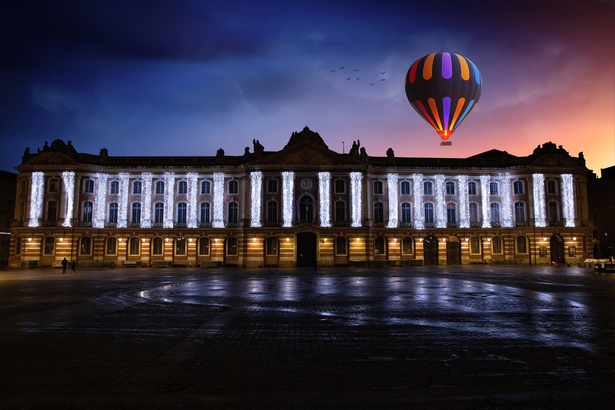

Tourisme en Occitanie, Toulouse - Photo libre de droit (Pixabay.com)

Tous ces arguments place l’Occitanie en zone d’attractivité touristique d’importance, la mettant `parmi les 3 premières destinations touristiques françaises`. *Elle réunit à elle seule tous les univers de vacances* : la campagne, la montagne, la mer et la ville **(source : tourisme-occitanie.com)**

## Raconte moi l’Histoire des Nuitées

Le fichier `nuitees.csv` synthétise la localisation et le comptage tout au long de l’année chaque nuit, des milliers de touristes dormant dans notre belle région **(source: Toulouse-Dataviz)**. Voyons ce qu’il va nous révéler…

### Totaux et Moyennes des nuitées en Occitanie

**En 2018**, la région Occitanie a enregistré **au total 200 753 905 nuitées** et **en moyenne 550 011 nuitées** sur 365 jours *(sauf pour les 2018-12-03 et le 2018-08-29, le nombre de nuitées est égal à zéro par défaut de collecte)*.

*Les moyennes des nuitées ont éte arrondies à l’entier le plus proche (fonction round).*

[figure not shown]

Figure 1 : Distribution en nuages de point des nuitéés cumuléées en Occitanie

*Entre 1er janvier 2018 et le 30 mars 2018 (presque 4 mois), seule la nuitée du 1er Janvier (post-fete du nouvel an !), dépasse la moyenne des nuitées cumulées sur l’année.*

Cette premiére indication, nous donne accès à une répartition mensuelle des nuitées en Occitanie, dans le tableau et le visuel ci-après :

| Mois | Total nuitées par mois | Moyenne nuitées par mois |
| --- | --- | --- |
| 1 | 8561728 | 276185 |
| 2 | 9122917 | 325818 |
| 3 | 11124692 | 358861 |
| 4 | 13920650 | 464022 |
| 5 | 14635826 | 472123 |
| 6 | 17530156 | 584339 |
| 7 | 32472883 | 1047512 |
| 8 | 36819700 | 1187732 |
| 9 | 19214826 | 640494 |
| 10 | 14916995 | 481193 |

[output cut: 2 more lines]

Figure 2 : Evolution des nuitées cumulées en Occitanie

[figure not shown]

Figure 2 : Evolution des nuitées cumulées en Occitanie

C’est ainsi qu’au cours de l’année 2018, deux mois dépassent la barre des 30 millions de nuitées : `Aout et Juillet`, avec respectivement **36 819 700 (soit 18.34%)** et **32 472 883 (soit 16.18%)** de nuitées. Un duo de fin ne dépasse pas la barre des 10 millions de nuitées : `Janvier et Février`, avec respectivement **8 561 728 (soit 4.26%)** et **9 122 917 (soit 4.54%)** de nuitées.

### Les TOP 10 des nuitées en Occitanie

| Date | Total des nuitées |
| --- | --- |
| 2018-08-04 | 1378565 |
| 2018-08-10 | 1394178 |
| 2018-08-11 | 1449824 |
| 2018-08-12 | 1391838 |
| 2018-08-13 | 1406820 |
| 2018-08-14 | 1491112 |
| 2018-08-15 | 1424648 |
| 2018-08-16 | 1378284 |
| 2018-08-17 | 1425739 |
| 2018-08-18 | 1397901 |

Le `Top 10 des nuitées cumulées en Occitanie` ont eu lieu `du 04 au 18 Aout 2018`, soit **14 138 909 nuitées (7.04% de la totalité des nuitées sur l’année)** dont *9 nuitées à la suite (du 10 au 18 Aout)* durant les vacances d’été.

| Date | Mois | Total des nuitées |
| --- | --- | --- |
| 2018-01-01 | 1 | 927930 |
| 2018-02-24 | 2 | 456746 |
| 2018-03-31 | 3 | 724907 |
| 2018-04-01 | 4 | 640227 |
| 2018-05-11 | 5 | 745769 |
| 2018-06-30 | 6 | 936580 |
| 2018-07-28 | 7 | 1352904 |
| 2018-08-14 | 8 | 1491112 |
| 2018-09-01 | 9 | 902056 |
| 2018-10-27 | 10 | 620747 |

[output cut: 2 more lines]

Le `Top des nuitées pour chaque mois en Occitanie` accumule **10 245 302 nuitées (5.1% de la totalité des nuitées sur l’année)**. Une seule nuitée, celle du 24 fevrier 2018, est en dessous de la moyenne cumulée sur l’année 2018 (550 011 nuitées).

### Evolution des nuitées en Occitanie et par Département

[figure not shown]

Les visuels ci-dessus, nous montre l’evolution des nuitées en Occitanie, repartie :

1. sur l’ensemble du territoire de la région Occitanie, nuitée par nuitée (jour après jour), nous observons l’évolution de nuitées cumulées et des moyennes de ces nuitées, avec un pic durant la période d’été.

2.enfin, nous observons l’evolution de ces nuitées sur l’ensemble des 13 départements de la région Occitanie, avec un trio en tete de fil, respectivement : *le Hérault (34, le premier)*, les Pyrénées-Orientales (66) et le Gard (30). En bas du classement, un autre trio, dans l’ordre : *le Tarn (81, le dernier)*, l’Ariège (09) et la Lozère (48).

3. A noter que la Haute-Garonne (31), suit une tendance similaire avec une apogée des nuitées en Juillet-Aout, une seconde vague d’intéret entre Octobre et Novembre et au final durant les 3 derniers jours autour du nouvel an.

### Les BOTTOM 10 des nuitées en Occitanie

| Date | Total des nuitées |
| --- | --- |
| 2018-01-14 | 205684 |
| 2018-01-22 | 142451 |
| 2018-01-23 | 150605 |
| 2018-01-30 | 185147 |
| 2018-02-04 | 178212 |
| 2018-03-14 | 73648 |
| 2018-03-15 | 83811 |
| 2018-05-06 | 194220 |
| 2018-05-20 | 104809 |
| 2018-05-21 | 64160 |

Le `Bottom 10 des nuitées cumulées en Occitanie` comprend des dates allant `du 14 Janvier au 21 Mai 2018`, soit **1 382 747 nuitées (0.689% de la totalité des nuitées sur l’année)** dont *4 nuitées en Janvier, 3 nuitées en Mai, 2 en Mars et 1 derniere en Février*. Etonnement (a priori c’est le beau temps/printemps), la nuitée du 21 Mai 2018 est celle qui cloture la bas de l’echelle de cetet année 2018, avec seulement 64 160 nuitées.

# Tentative De Synthèse

## Visuels : Cartographie + Graphe

[figure not shown]